# HAR Machine Learning Analysis

## Introduction

In this document we explore the data provided when users were performing weight lifting exercises.

More information on the study could be found at

http://groupware.les.inf.puc-rio.br/har

Participants were asked to perform one set of 10 repetitions of the Unilateral Dumbbell Biceps Curl in five different fashions: exactly according to the specification (Class A), throwing the elbows to the front (Class B), lifting the dumbbell only halfway (Class C), lowering the dumbbell only halfway (Class D) and throwing the hips to the front (Class E). Class A corresponds to the specified execution of the exercise, while the other 4 classes correspond to common mistakes.

Our goal is to come up with a machine learning prediction model where we can predict based on the data provided whether a user is doing the excercise correctly (Class A) or not (Other classes).

In the initial setup, the seed is set so we can reproduce the results. Also the doParallel package is loaded for using the multiple cores while training. Caret and other required packages are loaded.

## Initial Setup

The training set is loaded and split up as the actual training and testing sets. Only the columns that have no NA’s are used for model creation.

```r
training_orig<-read.csv("pml-training.csv")
testing_orig<-read.csv("pml-testing.csv")
inTrain<-createDataPartition(y=training_orig$classe, p=0.70,list=F)
training<-training_orig[inTrain,]
testing<-training_orig[-inTrain,]
```

Picking only columns needed for building the model.

```r
cols<-c(
"roll_belt","pitch_belt","yaw_belt","total_accel_belt",
"gyros_belt_x","gyros_belt_y","gyros_belt_z","accel_belt_x","accel_belt_y","accel_belt_z",
"magnet_belt_x","magnet_belt_y","magnet_belt_z",
"roll_arm","pitch_arm","yaw_arm","total_accel_arm",
"gyros_arm_x","gyros_arm_y","gyros_arm_z","accel_arm_x","accel_arm_y","accel_arm_z",
"magnet_arm_x","magnet_arm_y","magnet_arm_z",
"roll_dumbbell","pitch_dumbbell","yaw_dumbbell","total_accel_dumbbell",
"gyros_dumbbell_x","gyros_dumbbell_y","gyros_dumbbell_z","accel_dumbbell_x","accel_dumbbell_y","accel_dumbbell_z",
"magnet_dumbbell_x","magnet_dumbbell_y","magnet_dumbbell_z",
"roll_forearm","pitch_forearm","yaw_forearm","total_accel_forearm",
"gyros_forearm_x","gyros_forearm_y","gyros_forearm_z","accel_forearm_x","accel_forearm_y","accel_forearm_z",
"magnet_forearm_x","magnet_forearm_y","magnet_forearm_z",
"classe")
```

## Exploring Data

Lets get one user and try to find out the differences when he did the excercise in different ways.

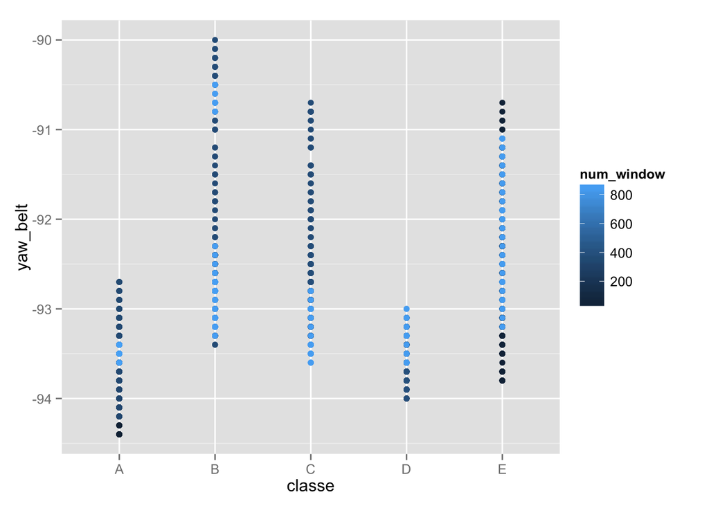

```r
carlitos<-training[training[,"user_name"]=="carlitos",]
qplot(classe,yaw_belt,color=num_window,data=carlitos)
```

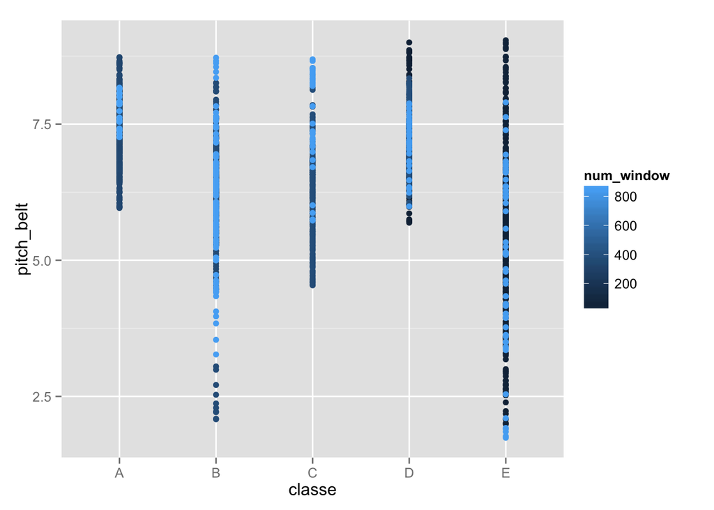

```r
qplot(classe,pitch_belt,color=num_window,data=carlitos)
```

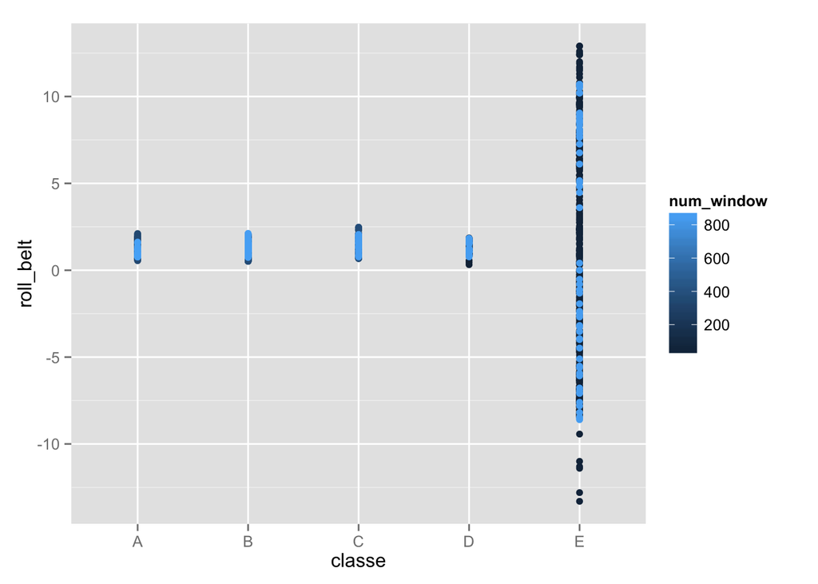

```r
qplot(classe,roll_belt,color=num_window,data=carlitos)
```

## Model Creation

Lets create Random Forest model. I am only showing the final model for brevity, I have tried with rpart, but the accuracy is very low (Around 50%).

```r
model<-train(classe~.,data=training[,cols],method="rf",
             trControl = trainControl(method="cv",number=4),
           preProcess = c("pca"))
```

Lets look at the model

```r
model
```

```
## Random Forest
##
## 13737 samples
##    52 predictor
##     5 classes: 'A', 'B', 'C', 'D', 'E'
##
## Pre-processing: principal component signal extraction, scaled, centered
## Resampling: Cross-Validated (4 fold)
##
## Summary of sample sizes: 10303, 10302, 10303, 10303
##
## Resampling results across tuning parameters:
##
##   mtry  Accuracy  Kappa  Accuracy SD  Kappa SD
##    2    1         1.0    0.003        0.004
##   27    1         0.9    0.005        0.007
##   52    1         0.9    0.005        0.006
##
## Accuracy was used to select the optimal model using  the largest value.
## The final value used for the model was mtry = 2.
```

## Cross Validation

Predict the output of the testing data set and find out the accuracy using confusionMatrix function

```r
output<-predict(model,testing)
confusionMatrix(testing$classe,output)
```

```
## Confusion Matrix and Statistics
##
##           Reference
## Prediction    A    B    C    D    E
##          A 1664    3    3    2    2
##          B   23 1097   17    0    2
##          C    2   17  998    7    2
##          D    1    1   31  928    3
##          E    1    5    5    4 1067
##
## Overall Statistics
##
##                Accuracy : 0.978
##                  95% CI : (0.974, 0.981)
##     No Information Rate : 0.287
##     P-Value [Acc > NIR] : < 2e-16
##
##                   Kappa : 0.972
##  Mcnemar's Test P-Value : 0.000119
##
## Statistics by Class:
##
##                      Class: A Class: B Class: C Class: D Class: E
## Sensitivity             0.984    0.977    0.947    0.986    0.992
## Specificity             0.998    0.991    0.994    0.993    0.997
## Pos Pred Value          0.994    0.963    0.973    0.963    0.986
## Neg Pred Value          0.994    0.995    0.988    0.997    0.998
## Prevalence              0.287    0.191    0.179    0.160    0.183
## Detection Rate          0.283    0.186    0.170    0.158    0.181
## Detection Prevalence    0.284    0.194    0.174    0.164    0.184
## Balanced Accuracy       0.991    0.984    0.971    0.989    0.994
```

Finally we test our model on the 20 observations that have been kept aside.

```r
predict(model,testing_orig)
```

```
##  [1] B A A A A E D B A A B C B A E E A B B B
## Levels: A B C D E
```